# ME344 Final Project: Train, Tune, And Scale Qwen3-4B on a TPU v5e-8

**Run id:** `qanh-20260813t194806z` · **Student:** qanh · **Hardware:** 1 host, 8 × TPU v5e (2×4 ICI)

This notebook is a report over the artifact files that the run wrote. It performs no TPU work: every table and figure below is computed from a file in `artifacts/qanh-20260813t194806z/`, and each cell prints the file it read so any number here can be traced to its source.

The GKE scaling section is the one exception to "this run produced it", and says so inline.

```python
import csv, json, statistics
from pathlib import Path
import matplotlib.pyplot as plt

RUN_ID = "qanh-20260813t194806z"
ARTIFACTS = next(
    p for p in (Path("artifacts") / RUN_ID, Path("../artifacts") / RUN_ID, Path(".") / RUN_ID)
    if p.is_dir()
)

def source(name):
    "Print provenance for the file about to be read, then return its path."
    path = ARTIFACTS / name
    size = path.stat().st_size
    print(f"source: {path.as_posix()}  ({size:,} bytes)")
    return path

def load_json(name):
    return json.loads(source(name).read_text())

def load_csv(name):
    with source(name).open() as handle:
        return list(csv.DictReader(handle))

def load_jsonl(name):
    with source(name).open() as handle:
        return [json.loads(line) for line in handle if line.strip()]

def table(rows, headers):
    widths = [max(len(str(h)), *(len(str(r[i])) for r in rows)) for i, h in enumerate(headers)]
    line = "  ".join(str(h).ljust(w) for h, w in zip(headers, widths))
    print(line)
    print("  ".join("-" * w for w in widths))
    for row in rows:
        print("  ".join(str(c).ljust(w) for c, w in zip(row, widths)))

plt.rcParams.update({"figure.figsize": (7.5, 4), "axes.grid": True, "grid.alpha": 0.3,
                     "font.size": 10, "axes.spines.top": False, "axes.spines.right": False})
config = load_json("config.json")
print()
print("assignment version:", config.get("assignment_version"))
print("maxtext commit:    ", config.get("maxtext_commit") or config.get("pinned_maxtext_commit"))
print("run id:            ", config.get("run_id"))
```

```
source: artifacts/qanh-20260813t194806z/config.json  (3,070 bytes)

assignment version: 2026.08.02.2
maxtext commit:     None
run id:             qanh-20260813t194806z
```

## 1. Will the first training step fit, before paying for it?

Ahead-of-time compilation answers the memory question without holding the chips. Two layouts were predicted and then both were run, including one predicted to fail.

```python
capacity = load_json("capacity_report.json")
hardware, model = capacity["hardware"], capacity["model"]
print()
print(f"parameters:                    {model['parameter_count_estimate']:,}")
print(f"BF16 checkpoint:               {model['bf16_checkpoint_gib']:.2f} GiB")
print(f"FP32 weights:                  {model['fp32_parameters_gib']:.2f} GiB")
print(f"persistent training state:     {model['persistent_training_state_gib']:.2f} GiB")
print(f"transient FP32 gradient:       {model['transient_fp32_gradient_gib']:.2f} GiB")
print(f"rough peak before activations: {model['rough_peak_before_activations_gib']:.2f} GiB")
print(f"HBM per chip (nominal):        {hardware['hbm_gib_per_chip']:.2f} GiB"
      f"  |  aggregate {hardware['aggregate_hbm_gib']:.1f} GiB over {hardware['chips']} chips")
print()

rows = []
for case in capacity["cases"]:
    rows.append([
        case["name"], case["tensor"], case["optimistic_state_shards"],
        f"{case['training_gib_per_chip']:.2f}", case["prediction"], case["observed"],
        f"{case.get('aot_reported_total_gib_per_chip', float('nan')):.2f}"
        if "aot_reported_total_gib_per_chip" in case else "n/a",
    ])
table(rows, ["case", "TP", "state shards", "predicted GiB/chip", "prediction", "observed", "AOT total GiB/chip"])
print()
oom = [c for c in capacity["cases"] if c["observed"] == "oom"]
if oom:
    print("evidence for the deliberate failure:")
    print(" ", oom[0]["evidence_excerpt"])
print()
print("derived rule: MaxText Adam training state is about 12 bytes/parameter persistent")
print(f"  check: 12 * {model['parameter_count_estimate']:,} / 2**30 ="
      f" {12 * model['parameter_count_estimate'] / 2**30:.2f} GiB"
      f"  vs reported {model['persistent_training_state_gib']:.2f} GiB")
print("  plus a transient FP32 gradient of 4 bytes/parameter, so ~16 bytes/parameter at peak")
```

```
source: artifacts/qanh-20260813t194806z/capacity_report.json  (2,346 bytes)

parameters:                    4,022,468,096
BF16 checkpoint:               7.49 GiB
FP32 weights:                  14.98 GiB
persistent training state:     44.95 GiB
transient FP32 gradient:       14.98 GiB
rough peak before activations: 59.94 GiB
HBM per chip (nominal):        14.90 GiB  |  aggregate 119.2 GiB over 8 chips

case     TP  state shards  predicted GiB/chip  prediction     observed  AOT total GiB/chip
-------  --  ------------  ------------------  -------------  --------  ------------------
TP8 AOT  8   8             7.49                fit_candidate  fit       8.23
DP8 AOT  1   1             59.94               oom            oom       n/a

evidence for the deliberate failure:
  jax.errors.JaxRuntimeError: RESOURCE_EXHAUSTED: Ran out of memory on HBM, the total memory required for HLO temporaries (65.47G) exceeds available HBM (15.75G).

derived rule: MaxText Adam training state is about 12 bytes/parameter persistent
  check: 12 * 4,022,468,096 / 2**30 = 44.95 GiB  vs reported 44.95 GiB
  plus a transient FP32 gradient of 4 bytes/parameter, so ~16 bytes/parameter at peak
```

## 2. How much work should one step hold?

Eight global batch sizes at sequence length 256, each AOT-checked first and then measured. The memory boundary and the throughput knee turn out to be different shapes.

```python
sweep = load_csv("sweep_results.csv")
measured = [r for r in sweep if r["benchmark_status"] == "measured"]
print()

rows = []
for r in sweep:
    fit = r["aot_status"]
    rows.append([
        r["global_batch"], r["per_device_batch"],
        f"{float(r['aot_reported_total_gib_per_chip']):.2f}" if r["aot_reported_total_gib_per_chip"] else "-",
        f"{float(r['aot_reported_total_percent_of_limit']):.1f}%" if r["aot_reported_total_percent_of_limit"] else "-",
        fit,
        f"{float(r['steady_step_sec']):.4f}" if r["steady_step_sec"] else "-",
        f"{float(r['total_tokens_per_sec']):,.0f}" if r["total_tokens_per_sec"] else "-",
        f"{float(r['tflops_per_sec_per_device']):.2f}" if r["tflops_per_sec_per_device"] else "-",
    ])
table(rows, ["global batch", "per device", "AOT GiB/chip", "% of limit", "AOT", "steady step s", "tokens/s", "TFLOP/s/dev"])

oom_rows = [r for r in sweep if r["aot_status"] == "oom"]
print()
for r in oom_rows:
    print(f"first OOM at global batch {r['global_batch']}: needs"
          f" {float(r['oom_required_temporary_gib_per_chip']):.2f} GiB temporaries"
          f" against {float(r['oom_available_hbm_gib_per_chip']):.2f} GiB available")

best = max(measured, key=lambda r: float(r["total_tokens_per_sec"]))
knee = min(
    (r for r in measured
     if float(r["total_tokens_per_sec"]) >= 0.99 * float(best["total_tokens_per_sec"])),
    key=lambda r: int(r["global_batch"]),
)
print()
print(f"peak throughput:  global batch {best['global_batch']} at {float(best['total_tokens_per_sec']):,.0f} tokens/s")
print(f"knee (within 1% of peak, smallest batch): global batch {knee['global_batch']}"
      f" at {float(knee['total_tokens_per_sec']):,.0f} tokens/s"
      f" using {float(knee['aot_reported_total_percent_of_limit']):.1f}% of the HBM limit")
print(f"so the useful shape is {knee['global_batch']} while the memory wall is"
      f" {oom_rows[0]['global_batch'] if oom_rows else 'n/a'}:"
      f" {len([r for r in sweep if int(r['global_batch']) > int(knee['global_batch'])])} doublings apart")
```

```
source: artifacts/qanh-20260813t194806z/sweep_results.csv  (3,685 bytes)

global batch  per device  AOT GiB/chip  % of limit  AOT  steady step s  tokens/s  TFLOP/s/dev
------------  ----------  ------------  ----------  ---  -------------  --------  -----------
4             0.5         8.23          52.2%       fit  0.0979         10,457    31.84
8             1.0         8.36          53.1%       fit  0.1537         13,322    40.57
16            2.0         9.00          57.2%       fit  0.2666         15,361    46.78
32            4.0         9.35          59.4%       fit  0.4946         16,562    50.43
64            8.0         10.60         67.3%       fit  0.9849         16,635    50.65
128           16.0        12.99         82.5%       fit  1.9708         16,627    50.63
256           32.0        17.37         110.3%      fit  4.0386         16,227    49.41
512           64.0        -             -           oom  -              -         -

first OOM at global batch 512: needs 18.43 GiB temporaries against 15.75 GiB available

peak throughput:  global batch 64 at 16,635 tokens/s
knee (within 1% of peak, smallest batch): global batch 32 at 16,562 tokens/s using 59.4% of the HBM limit
so the useful shape is 32 while the memory wall is 512: 4 doublings apart
```

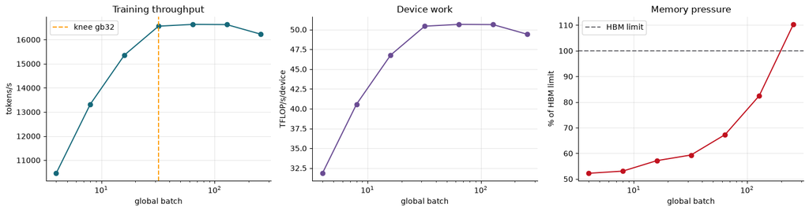

```
figure computed from sweep_results.csv; the run's own version is sweep.svg
```

```python
batches = [int(r["global_batch"]) for r in measured]
figure, axes = plt.subplots(1, 3, figsize=(15, 4))
axes[0].plot(batches, [float(r["total_tokens_per_sec"]) for r in measured], "o-", color="#16697a")
axes[0].axvline(int(knee["global_batch"]), ls="--", c="#ff9f0a", label=f"knee gb{knee['global_batch']}")
axes[0].set(xscale="log", xlabel="global batch", ylabel="tokens/s", title="Training throughput")
axes[0].legend()
axes[1].plot(batches, [float(r["tflops_per_sec_per_device"]) for r in measured], "o-", color="#6a4c93")
axes[1].set(xscale="log", xlabel="global batch", ylabel="TFLOP/s/device", title="Device work")
axes[2].plot(batches, [float(r["aot_reported_total_percent_of_limit"]) for r in measured], "o-", color="#c1121f")
axes[2].axhline(100, ls="--", c="#6e6e73", label="HBM limit")
axes[2].set(xscale="log", xlabel="global batch", ylabel="% of HBM limit", title="Memory pressure")
axes[2].legend()
figure.tight_layout()
plt.show()
print("figure computed from sweep_results.csv; the run's own version is sweep.svg")
```

## 3. How much hardware headroom is left?

Against a 6 · parameters · tokens lower bound and the published 197 BF16 TFLOP/s peak.

```python
bound = load_json("compute_bound.json")
print()
rows = [[
    c["global_batch"], f"{c['tokens_per_step']:,}",
    f"{c['peak_compute_lower_bound_seconds']:.4f}",
    f"{c['measured_steady_step_seconds']:.4f}",
    f"{c['time_efficiency_percent']:.1f}%",
    f"{c['measured_peak_tflops_percent']:.1f}%",
] for c in bound["cases"]]
table(rows, ["global batch", "tokens/step", "bound s", "measured s", "time efficiency", "% of BF16 peak"])
print()
peak = max(bound["cases"], key=lambda c: c["measured_peak_tflops_percent"])
print(f"best utilization: {peak['measured_peak_tflops_percent']:.1f}% of peak at global batch {peak['global_batch']}")
print("the curve flattens rather than climbing, so the rest is not recoverable by a bigger step")
print()
for note in bound.get("assumptions", []):
    print(" -", note)
```

```
source: artifacts/qanh-20260813t194806z/compute_bound.json  (2,856 bytes)

global batch  tokens/step  bound s  measured s  time efficiency  % of BF16 peak
------------  -----------  -------  ----------  ---------------  --------------
4             1,024        0.0157   0.0979      16.0%            16.2%
8             2,048        0.0314   0.1537      20.4%            20.6%
16            4,096        0.0627   0.2666      23.5%            23.7%
32            8,192        0.1255   0.4946      25.4%            25.6%
64            16,384       0.2509   0.9849      25.5%            25.7%
128           32,768       0.5018   1.9708      25.5%            25.7%
256           65,536       1.0036   4.0386      24.9%            25.1%

best utilization: 25.7% of peak at global batch 64
the curve flattens rather than climbing, so the rest is not recoverable by a bigger step

 - Dense-transformer training is approximated as 6 * parameters * tokens FLOPs.
 - All eight chips sustain the published 197 BF16 TFLOP/s peak with no communication or stalls.
 - The bound is optimistic; measured/peak TFLOPs is a utilization proxy, not model FLOPs utilization.
```

## 4. Where does a training step spend its time?

Parsed from the XProf capture: 3 profiled steps after 3 warmup steps.

```python
profile_text = source("profile.log").read_text()
print()
flop_lines = [l for l in profile_text.splitlines()
              if "Total TFLOPs" in l or "split as" in l or "Per train step" in l]
for line in flop_lines[:6]:
    print(line.strip())

steps = []
for line in profile_text.splitlines():
    if "completed step:" in line and "TFLOP/s/device" in line:
        parts = dict(
            piece.strip().split(": ", 1)
            for piece in line.split("] ", 1)[-1].split(", ") if ": " in piece
        )
        try:
            steps.append((int(float(parts["completed step"])), float(parts["seconds"]),
                          float(parts["TFLOP/s/device"])))
        except (KeyError, ValueError):
            pass
print()
table([[s, f"{sec:.3f}", f"{tf:,.1f}"] for s, sec, tf in steps],
      ["step", "seconds", "TFLOP/s/device"])
print()
print("note: the profiler distorts the step it instruments; the sub-0.05 s steps with")
print("implausible TFLOP/s are measurement artifacts, not real throughput.")
plausible = [tf for _, sec, tf in steps if sec > 0.05]
if plausible:
    print(f"median TFLOP/s/device over plausible steps: {statistics.median(plausible):,.1f}")
print()
print("xprof invocation recorded in:", (ARTIFACTS / "xprof_command.txt").as_posix())
print(source("xprof_command.txt").read_text().strip()[:400])
```

```
source: artifacts/qanh-20260813t194806z/profile.log  (10,470 bytes)

Per train step:
Total TFLOPs: 24.94
split as 99.07% learnable weight flops and 0.93% attention flops

step  seconds  TFLOP/s/device
----  -------  --------------
0     0.752    33.2
1     0.282    88.5
2     0.323    77.3
3     0.931    26.8
4     0.011    2,301.4
5     0.492    50.7
6     20.201   1.2
7     0.007    3,560.0
8     0.494    50.5
9     0.495    50.4

note: the profiler distorts the step it instruments; the sub-0.05 s steps with
implausible TFLOP/s are measurement artifacts, not real throughput.
median TFLOP/s/device over plausible steps: 50.4

xprof invocation recorded in: artifacts/qanh-20260813t194806z/xprof_command.txt
source: artifacts/qanh-20260813t194806z/xprof_command.txt  (327 bytes)
source /home/student49/me344_final_project/.venv-me344-pretrain/bin/activate
xprof --logdir=/home/student49/me344-artifacts/qanh-20260813t194806z/xprof_profile/tensorboard --port=6006
# Laptop: open http://127.0.0.1:6006 through the existing SSH tunnels.
# In XProf, inspect Overview Page, Trace Viewer, and Roofline Analysis.
```

## 5. Fine-tuning: what changed?

200 SFT steps at global batch 4, sequence length 256, learning rate 3e-6, then 2 more steps after a deliberate resume.

```
source: artifacts/qanh-20260813t194806z/sft_metrics.jsonl  (102,652 bytes)
source: artifacts/qanh-20260813t194806z/sft_resume_metrics.jsonl  (1,009 bytes)

train points: 200   eval points: 9   resume train points: 2
first train loss: 0.696695 at step 1
final train loss: 0.007942 at step 200
first eval avg loss: 0.805836 (perplexity 2.239)
final eval avg loss: 0.062256 (perplexity 1.181)

loss before resume: 0.007942
first loss after resume: 0.012250 at step 201
resume continued at the next optimizer step rather than restarting at step 1
```

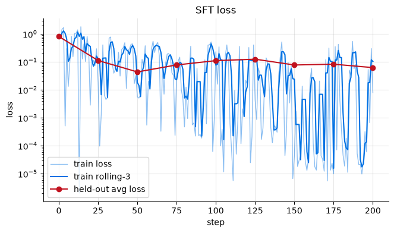

```python
sft = load_jsonl("sft_metrics.jsonl")
resume = load_jsonl("sft_resume_metrics.jsonl")
train = [r for r in sft if "learning/loss" in r]
evals = [r for r in sft if "eval/avg_loss" in r]
resume_train = [r for r in resume if "learning/loss" in r]
print()
print(f"train points: {len(train)}   eval points: {len(evals)}   resume train points: {len(resume_train)}")
print(f"first train loss: {train[0]['learning/loss']:.6f} at step {train[0]['step']:.0f}")
print(f"final train loss: {train[-1]['learning/loss']:.6f} at step {train[-1]['step']:.0f}")
print(f"first eval avg loss: {evals[0]['eval/avg_loss']:.6f} (perplexity {evals[0]['eval/avg_perplexity']:.3f})")
print(f"final eval avg loss: {evals[-1]['eval/avg_loss']:.6f} (perplexity {evals[-1]['eval/avg_perplexity']:.3f})")
if resume_train:
    print()
    print(f"loss before resume: {train[-1]['learning/loss']:.6f}")
    print(f"first loss after resume: {resume_train[0]['learning/loss']:.6f}"
          f" at step {resume_train[0]['step']:.0f}")
    print("resume continued at the next optimizer step rather than restarting at step 1")

figure, axis = plt.subplots()
axis.plot([r["step"] for r in train], [r["learning/loss"] for r in train],
          lw=1, alpha=0.45, color="#0071e3", label="train loss")
rolling = [statistics.fmean([r["learning/loss"] for r in train[max(0, i - 2):i + 1]])
           for i in range(len(train))]
axis.plot([r["step"] for r in train], rolling, color="#0071e3", label="train rolling-3")
axis.plot([r["step"] for r in evals], [r["eval/avg_loss"] for r in evals],
          "o-", color="#c1121f", label="held-out avg loss")
axis.set(yscale="log", xlabel="step", ylabel="loss", title="SFT loss")
axis.legend()
plt.show()
```

## 6. The stopping rule disagrees with training longer

The run computes its own stop/continue recommendation from the held-out curve.

```python
decision = load_json("training_decision.json")
recovery = load_json("recovery_report.json")
print()
print(f"best held-out loss:        {decision['best_held_out_loss']:.6f} at step {decision['best_held_out_step']}")
print(f"last minus best:           {decision['last_minus_best_held_out_loss']:.6f}")
print(f"intervals since best:      {decision['evaluation_intervals_since_best']}")
print(f"generalization gap at last: {decision['generalization_gap_at_last_eval']:.6f}")
print(f"initial run steps:         {decision['initial_run_steps']}")
print()
print("decision rule:  ", decision["decision_rule"])
print("recommendation: ", decision["recommendation"])
print()
curve = decision.get("held_out_curve") or decision.get("evaluations") or []
if curve:
    table([[p["step"], f"{p['loss']:.6f}"] for p in curve], ["step", "held-out loss"])
print()
print("recovery report keys:", ", ".join(sorted(recovery)))
for key in ("rollback_step", "resumed_step", "resume_behavior", "next_step"):
    if key in recovery:
        print(f"  {key}: {recovery[key]}")
print()
print("This is the tension worth naming: the task metric prefers step 202, the held-out loss")
print(f"prefers step {decision['best_held_out_step']}, and no task metric was ever run against"
      f" step {decision['best_held_out_step']}.")
```

```
source: artifacts/qanh-20260813t194806z/training_decision.json  (1,479 bytes)
source: artifacts/qanh-20260813t194806z/recovery_report.json  (693 bytes)

best held-out loss:        0.043622 at step 50
last minus best:           0.018633
intervals since best:      6
generalization gap at last: -0.040652
initial run steps:         200

decision rule:   Stop after two evaluations without a new held-out best, a task-metric regression, or the cost limit.
recommendation:  Stop or roll back: held-out loss has not set a new best for 6 evaluation intervals.


recovery report keys: final_checkpoint, first_loss_after_resume, loss_before_resume, optimizer_state_evidence, optimizer_state_restored, resumed_steps, rollback_checkpoint, rollback_step
  rollback_step: 200

This is the tension worth naming: the task metric prefers step 202, the held-out loss
prefers step 50, and no task metric was ever run against step 50.
```

## 7. GRPO: reward training is not the same as SFT

```python
rl = load_json("rl_summary.json")
pre, post, change = rl["pre"], rl["post"], rl["change"]
print()
table([
    ["exact correct", f"{pre['correct']}/{pre['total']}", f"{post['correct']}/{post['total']}",
     f"{change['accuracy_percentage_points']:+.1f} pts"],
    ["exact accuracy", f"{pre['accuracy_percent']:.2f}%", f"{post['accuracy_percent']:.2f}%",
     f"{change['accuracy_percentage_points']:+.1f} pts"],
    ["format compliance", f"{pre['format_accuracy_percent']:.2f}%", f"{post['format_accuracy_percent']:.2f}%",
     f"{change['format_percentage_points']:+.1f} pts"],
    ["mean reward", f"{pre['mean_reward']:.4f}", f"{post['mean_reward']:.4f}",
     f"{change['mean_reward']:+.4f}"],
], ["metric", "before", "after", "change"])
print()
print(f"reward improved:                 {rl['reward_improved']}")
print(f"exact accuracy guardrail passed: {rl['exact_accuracy_guardrail_passed']}")
signal = rl["training_signal"]
print()
print(f"groups: {signal['groups']}, with relative signal: {signal['groups_with_relative_signal']}"
      f" ({signal['groups_with_relative_signal_percent']:.1f}%)")
print(f"mean group reward span: {signal['mean_group_reward_span']:.4f}")
print("reward component means:", {k: round(v, 4) for k, v in signal["component_means"].items()})
print()
delta_examples = post["correct"] - pre["correct"]
print(f"CAUTION: the {change['accuracy_percentage_points']:+.1f} point accuracy change is"
      f" {delta_examples:+d} example(s) out of {post['total']}.")
print("An identically configured earlier run (qanh-20260810t005140z) produced -12.5 points on this")
print("same metric with the guardrail failing, so the sign of the accuracy effect is not stable")
print("at this sample size. The format gain (6/16 -> 15/16) is the part large enough to trust.")
```

```
source: artifacts/qanh-20260813t194806z/rl_summary.json  (1,925 bytes)

metric             before  after   change
-----------------  ------  ------  ---------
exact correct      10/16   12/16   +12.5 pts
exact accuracy     62.50%  75.00%  +12.5 pts
format compliance  37.50%  93.75%  +56.2 pts
mean reward        1.0671  1.5309  +0.4638

reward improved:                 True
exact accuracy guardrail passed: True

groups: 12, with relative signal: 11 (91.7%)
mean group reward span: 1.3639
reward component means: {'closeness': 0.0028, 'exact': 0.7292, 'format': 0.5198}

CAUTION: the +12.5 point accuracy change is +2 example(s) out of 16.
An identically configured earlier run (qanh-20260810t005140z) produced -12.5 points on this
same metric with the guardrail failing, so the sign of the accuracy effect is not stable
at this sample size. The format gain (6/16 -> 15/16) is the part large enough to trust.
```

## 8. Did fine-tuning help, and how confident can we be?

Primary suite: banking77 intent classification, 40 untouched rows. Retention suite: GSM8K.

```python
evaluation = load_csv("evaluation_results.csv")
print()
table([[
    r["label"], r["examples"], f"{float(r['exact_match_percent']):.1f}%",
    f"{float(r['format_compliance_percent']):.1f}%", r["mean_completion_tokens"],
    r["retention_examples"], f"{float(r['retention_exact_match_percent']):.2f}%",
    f"{float(r['retention_format_compliance_percent']):.2f}%",
] for r in evaluation],
    ["checkpoint", "n", "exact", "format", "mean tokens", "retention n", "retention exact", "retention format"])

base = next(r for r in evaluation if r["label"] == "base")
sft_row = next(r for r in evaluation if r["label"] == "sft")
gain = float(sft_row["exact_match_percent"]) - float(base["exact_match_percent"])
retention_gain = float(sft_row["retention_exact_match_percent"]) - float(base["retention_exact_match_percent"])
print()
print(f"domain gain: {gain:+.1f} points exact match")
print(f"retention:   {retention_gain:+.2f} points on GSM8K, so no retention regression")

uncertainty = load_json("evaluation_uncertainty.json")
print()
table([[
    m["label"], f"{m['successes']}/{m['trials']}", f"{m['observed_percent']:.1f}%",
    f"{m['wilson_95_low_percent']:.1f}%", f"{m['wilson_95_high_percent']:.1f}%",
] for m in uncertainty["models"]],
    ["checkpoint", "successes", "observed", "Wilson 95% low", "Wilson 95% high"])
print()
low_sft = next(m for m in uncertainty["models"] if m["label"] == "sft")["wilson_95_low_percent"]
high_base = next(m for m in uncertainty["models"] if m["label"] == "base")["wilson_95_high_percent"]
print(f"the SFT lower bound ({low_sft:.1f}%) and the base upper bound ({high_base:.1f}%)"
      f" {'still overlap' if low_sft < high_base else 'do not overlap'}"
      f" by {abs(high_base - low_sft):.1f} points")
print(f"samples needed for a +/-{uncertainty['target_margin_percentage_points']:.0f} point margin:"
      f" {uncertainty['worst_case_samples_for_target_margin']} (this suite used {base['examples']})")
print()
print("assumption:", uncertainty["assumption"])
print("decision:  ", uncertainty["decision"])
```

```
source: artifacts/qanh-20260813t194806z/evaluation_results.csv  (277 bytes)

checkpoint  n   exact  format  mean tokens  retention n  retention exact  retention format
----------  --  -----  ------  -----------  -----------  ---------------  ----------------
base        40  70.0%  100.0%  5.4          16           81.25%           75.00%
sft         40  92.5%  100.0%  5.575        16           87.50%           87.50%

domain gain: +22.5 points exact match
retention:   +6.25 points on GSM8K, so no retention regression
source: artifacts/qanh-20260813t194806z/evaluation_uncertainty.json  (851 bytes)

checkpoint  successes  observed  Wilson 95% low  Wilson 95% high
----------  ---------  --------  --------------  ---------------
base        28/40      70.0%     54.6%           81.9%
sft         37/40      92.5%     80.1%           97.4%

the SFT lower bound (80.1%) and the base upper bound (81.9%) still overlap by 1.8 points
samples needed for a +/-10 point margin: 97 (this suite used 40)

assumption: Prompts are independent and representative; Wilson intervals do not fix biased data.
decision:   Treat this suite as a release smoke test; use a larger representative set for a real launch.
```

## 9. Serving the chosen checkpoint

```python
serving = load_csv("serving_results.csv")
print()
table([[
    r["concurrency"], r["requests"], f"{float(r['requests_per_second']):.2f}",
    f"{float(r['ttft_p50_seconds']) * 1000:.1f} ms", f"{float(r['latency_p50_seconds']) * 1000:.1f} ms",
    f"{float(r['latency_p95_seconds']) * 1000:.1f} ms", f"{float(r['output_tokens_per_second']):.1f}",
    r["mean_output_tokens"],
] for r in serving],
    ["concurrency", "requests", "req/s", "TTFT p50", "latency p50", "latency p95", "output tok/s", "mean out tokens"])

low, high = serving[0], serving[-1]
throughput_ratio = float(high["requests_per_second"]) / float(low["requests_per_second"])
ttft_ratio = float(high["ttft_p50_seconds"]) / float(low["ttft_p50_seconds"])
concurrency_ratio = int(high["concurrency"]) / int(low["concurrency"])
print()
print(f"{concurrency_ratio:.0f}x concurrency buys {throughput_ratio:.2f}x throughput"
      f" for {ttft_ratio:.2f}x TTFT")
print(f"mean output is {float(high['mean_output_tokens']):.0f} tokens, so this measures a"
      f" short-generation classification workload, not long-form decoding")
```

```
source: artifacts/qanh-20260813t194806z/serving_results.csv  (579 bytes)

concurrency  requests  req/s  TTFT p50  latency p50  latency p95  output tok/s  mean out tokens
-----------  --------  -----  --------  -----------  -----------  ------------  ---------------
1            8         26.97  12.5 ms   35.1 ms      51.2 ms      161.8         6.0
4            8         75.48  23.8 ms   45.1 ms      63.1 ms      452.9         6.0

4x concurrency buys 2.80x throughput for 1.91x TTFT
mean output is 6 tokens, so this measures a short-generation classification workload, not long-form decoding
```

## 10. Can the same checkpoint run on more workers?

**Provenance note:** these five GKE JobSet results were produced on 2026-08-10 and reused here. `scale_out.json` records `source_checkpoint` from the earlier run, and the collection code checks only `student_id`, so nothing in the pipeline validates checkpoint identity. The cell below prints that field so the reuse is visible rather than hidden.

```python
scale = load_json("scale_out.json")
modes = ["baseline", "ici_strong", "ici_weak", "strong", "weak"]
print()
table([[
    m, scale[m]["chips"], scale[m]["fabric"], scale[m]["topology"], scale[m]["slices"],
    scale[m]["global_batch"], f"{scale[m]['steady_step_seconds']:.3f}",
    f"{scale[m]['tokens_per_second']:,.0f}", f"{scale[m]['tokens_per_second_per_chip']:,.0f}",
] for m in modes],
    ["mode", "chips", "fabric", "topology", "slices", "batch", "s/step", "tokens/s", "tokens/s/chip"])
print()
for key in ("ici_strong_scaling_efficiency_percent", "ici_weak_scaling_efficiency_percent",
            "strong_scaling_efficiency_percent", "weak_scaling_efficiency_percent",
            "ici_over_dcn_strong_ratio", "ici_over_dcn_weak_ratio"):
    print(f"{key}: {scale[key]:.2f}")
print()
print("source checkpoints recorded in the result files:")
for m in modes:
    print(f"  {m}: {scale[m]['source_checkpoint']}")
print()
print("exposed communication, backing ICI out of DCN at matched batch:")
strong_exposed = scale["strong"]["steady_step_seconds"] - scale["ici_strong"]["steady_step_seconds"]
weak_exposed = scale["weak"]["steady_step_seconds"] - scale["baseline"]["steady_step_seconds"]
print(f"  DCN strong (gb256): {scale['strong']['steady_step_seconds']:.3f}"
      f" - {scale['ici_strong']['steady_step_seconds']:.3f} = {strong_exposed:.2f} s")
print(f"  DCN weak   (gb512): {scale['weak']['steady_step_seconds']:.3f}"
      f" - {scale['baseline']['steady_step_seconds']:.3f} = {weak_exposed:.2f} s")
print(f"  ratio: {weak_exposed / strong_exposed:.1f}x the exposed cost for the same payload")
print()
print("The all-reduce payload is set by the model, not the batch, so doubling per-slice work")
print("should amortize a fixed cost better, not worse. Candidates: lost compute/communication")
print("overlap, rematerialization from running at 110% of the AOT limit, or DCN contention from")
print("other students. The GKE jobs saved no XProf traces, so these cannot be separated here.")
```

```
source: artifacts/qanh-20260813t194806z/scale_out.json  (5,403 bytes)

mode        chips  fabric  topology  slices  batch  s/step  tokens/s  tokens/s/chip
----------  -----  ------  --------  ------  -----  ------  --------  -------------
baseline    8      ICI     2x4       1       256    4.045   16,200    2,025
ici_strong  16     ICI     4x4       1       256    2.022   32,417    2,026
ici_weak    16     ICI     4x4       1       512    4.061   32,272    2,017
strong      16     DCN     2x4       2       256    3.104   21,123    1,320
weak        16     DCN     2x4       2       512    7.553   17,355    1,085

ici_strong_scaling_efficiency_percent: 100.05
ici_weak_scaling_efficiency_percent: 99.61
strong_scaling_efficiency_percent: 65.20
weak_scaling_efficiency_percent: 53.56
ici_over_dcn_strong_ratio: 1.53
ici_over_dcn_weak_ratio: 1.86

source checkpoints recorded in the result files:
  baseline: gs://me344-tpu-labs-west4/final_projects/qanh/runs/me344-qanh-20260810t005140z-c4/checkpoints/4/items
  ici_strong: gs://me344-tpu-labs-west4/final_projects/qanh/runs/me344-qanh-20260810t005140z-c4/checkpoints/4/items
  ici_weak: gs://me344-tpu-labs-west4/final_projects/qanh/runs/me344-qanh-20260810t005140z-c4/checkpoints/4/items
  strong: gs://me344-tpu-labs-west4/final_projects/qanh/runs/me344-qanh-20260810t005140z-c4/checkpoints/4/items
  weak: gs://me344-tpu-labs-west4/final_projects/qanh/runs/me344-qanh-20260810t005140z-c4/checkpoints/4/items

exposed communication, backing ICI out of DCN at matched batch:
  DCN strong (gb256): 3.104 - 2.022 = 1.08 s
  DCN weak   (gb512): 7.553 - 4.045 = 3.51 s
  ratio: 3.2x the exposed cost for the same payload

The all-reduce payload is set by the model, not the batch, so doubling per-slice work
should amortize a fixed cost better, not worse. Candidates: lost compute/communication
overlap, rematerialization from running at 110% of the AOT limit, or DCN contention from
other students. The GKE jobs saved no XProf traces, so these cannot be separated here.
```

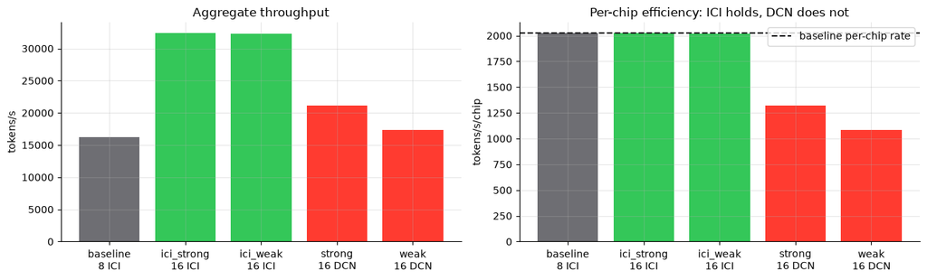

```python
figure, axes = plt.subplots(1, 2, figsize=(13, 4))
labels = ["baseline\n8 ICI", "ici_strong\n16 ICI", "ici_weak\n16 ICI", "strong\n16 DCN", "weak\n16 DCN"]
colors = ["#6e6e73", "#34c759", "#34c759", "#ff3b30", "#ff3b30"]
axes[0].bar(labels, [scale[m]["tokens_per_second"] for m in modes], color=colors)
axes[0].set(ylabel="tokens/s", title="Aggregate throughput")
axes[1].bar(labels, [scale[m]["tokens_per_second_per_chip"] for m in modes], color=colors)
axes[1].axhline(scale["baseline"]["tokens_per_second_per_chip"], ls="--", c="#1d1d1f",
                label="baseline per-chip rate")
axes[1].set(ylabel="tokens/s/chip", title="Per-chip efficiency: ICI holds, DCN does not")
axes[1].legend()
figure.tight_layout()
plt.show()
```

## 11. What did it cost?

```python
ledger = [r for r in load_csv("cost_ledger.csv") if r["kind"] == "command"]
grouped = {}
for row in ledger:
    stage = row["stage"]
    if stage.startswith("sweep-"):
        stage = "AOT batch frontier"
    elif stage.startswith("sft"):
        stage = "SFT + recovery"
    elif stage == "grpo" or stage.startswith("rl"):
        stage = "GRPO"
    elif stage.startswith("inference") or stage.startswith("vllm"):
        stage = "evaluation + serving"
    elif stage.startswith("capacity"):
        stage = "capacity lab"
    grouped[stage] = grouped.get(stage, 0.0) + float(row["estimated_usd"])
print()
table([[s, f"${c:.2f}"] for s, c in sorted(grouped.items(), key=lambda kv: -kv[1])],
      ["stage", "estimated USD"])
print()
print(f"total across {len(ledger)} recorded commands: ${sum(grouped.values()):.2f}")
failures = [r for r in ledger if r["returncode"] not in ("0", "")]
print(f"non-zero exits (including the deliberate OOM probes): {len(failures)}")
for row in failures:
    print(f"  {row['stage']}: rc={row['returncode']}, {float(row['wall_seconds']):.1f}s")
```

```
source: artifacts/qanh-20260813t194806z/cost_ledger.csv  (2,640 bytes)

stage                 estimated USD
--------------------  -------------
SFT + recovery        $1.76
AOT batch frontier    $1.45
GRPO                  $1.14
evaluation + serving  $0.66
continued-pretrain    $0.54
capacity lab          $0.17
xprof                 $0.16
smoke                 $0.09

total across 25 recorded commands: $5.96
non-zero exits (including the deliberate OOM probes): 2
  capacity-dp8-aot: rc=1, 24.1s
  sweep-aot-gb512: rc=1, 26.6s
```

## 12. The nine-panel dashboard the run produced

This is the figure that ships in the Canvas submission alongside `answers.md`.

```
source: artifacts/qanh-20260813t194806z/systems_dashboard.png  (374,072 bytes)
```

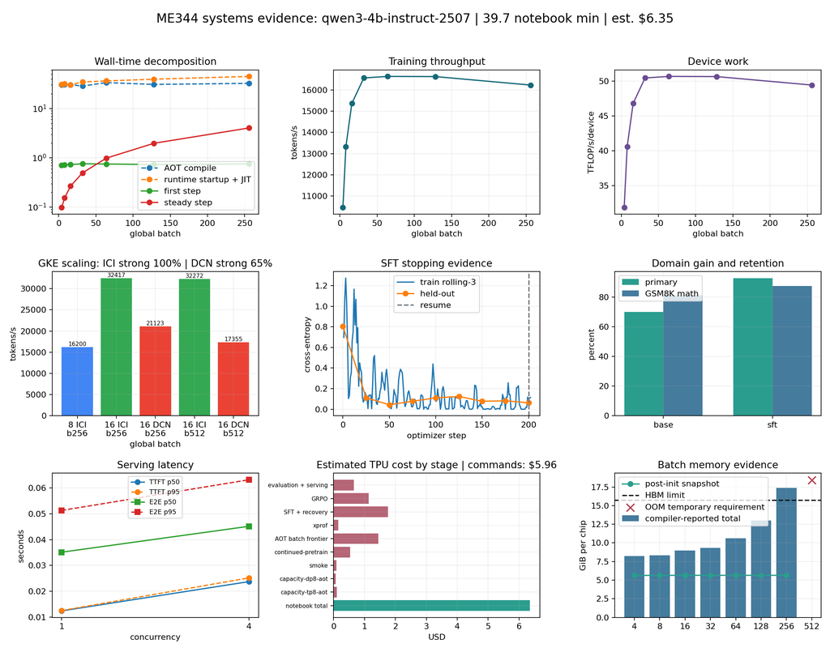

```python
from IPython.display import Image, display
path = source("systems_dashboard.png")
display(Image(filename=str(path)))
```

## 13. Recommendation

**Ship the SFT checkpoint at step 202.** It is the only candidate with a domain gain, no retention regression, and a serving measurement behind it: banking77 exact match 70.0% to 92.5%, GSM8K retention 81.25% to 87.5%, and 27.0 req/s at concurrency 1 rising to 75.5 req/s at concurrency 4.

**Do not lean on the GRPO checkpoint**, even though its guardrail passed in this run. Its +12.5 point accuracy change is two examples out of sixteen, and an identically configured earlier run produced -12.5 points with the guardrail failing. The format gain (6/16 to 15/16) is the part large enough to trust.

**Hold all of it as a smoke test, not a launch decision.** The 95% Wilson interval for SFT (80.1% to 97.4%) still overlaps the base interval (54.6% to 81.9%), and a plus-or-minus 10 point margin would need 97 examples rather than 40.

**Two open measurement gaps.** DCN weak scaling is worse per chip than DCN strong, which a fixed-size all-reduce should not do, and the GKE jobs saved no traces to explain it. And the stopping rule prefers step 50, which no task metric has ever been run against.